# Proyecto Modulo 2 - Parte 2. Palabra: Retrogade

Author

Becerra Ayala Anay

```r
knitr::opts_chunk$set(message = FALSE, warning = FALSE)
```

```r
library(reticulate)
```

```r
#py_install(c("pandas", "matplotlib", "requests"))
```

```r
py_run_string("
import pandas as pd # manejar tablas, limpiar datos y crear el csv
import matplotlib.pyplot as plt
import requests
import time
from datetime import datetime, timedelta
")
```

- para poder realizar solicitudes a la API APOD de la NASA, es necesario instalar la libreria `requests` en python, porque permite establecer comunicacion entre el programa en python y el servidor de la API
- para obtener informacion desde la API, hacemos una solicitud HTTP utilizando la libreria `requests` y establecer una conexion y recupera los datos

```r
py_run_string('
import os
import pandas as pd
from datetime import datetime, timedelta
import requests
import time

# nombre del archivo donde se guardan los datos
archivo_local = "datos_apod.csv"

# revisamos si el archivo ya existe para no repetir la descarga
if os.path.exists(archivo_local):
    print("¡Ya tienes los datos guardados! Cargando archivo local...")
    tabla = pd.read_csv(archivo_local)
    print("Total de registros cargados con éxito:", len(tabla))

else:
    # si el archivo no existe se inicia la descarga desde internet
    print("No encontré el archivo local. Iniciando descarga desde la API de la NASA...")

    clave_api = "gAOe9MAeZbWh23HpjGBnIrxEVLmdeVaxf9dHsykO"
    url = "[https://api.nasa.gov/planetary/apod](https://api.nasa.gov/planetary/apod)"

    fecha_inicio = datetime(1995, 6, 16) #rango de tiempo
    fecha_final = datetime(2026, 4, 30)

    bloque = timedelta(days=100) #intervalo de tiempo para evitar saturacion en la api

    lista_datos = [] #lista donde se guardan los datos

    while fecha_inicio <= fecha_final:

        if (fecha_inicio + bloque) > fecha_final: # definir el ultimo bloque para que no sobrepase la fecha final definida
            fecha_fin_bloque = fecha_final
        else:
            fecha_fin_bloque = fecha_inicio + bloque

        parametros = { #requisitos
            "api_key": clave_api,
            "start_date": fecha_inicio.strftime("%Y-%m-%d"),
            "end_date": fecha_fin_bloque.strftime("%Y-%m-%d")}

        # si falla no se detiene sino que lo intenta 3 veces
        intentos = 0
        max_intentos = 3
        exito = False

        while intentos < max_intentos and not exito:
            try:
                respuesta = requests.get(url, params=parametros)
                respuesta.raise_for_status() # Lanza un error si el codigo no es 200

                datos_bloque = respuesta.json()

                if isinstance(datos_bloque, list):
                    lista_datos.extend(datos_bloque) # extend() une la lista nueva a la lista principal sin crear sublistas
                    print(f"Bloque descargado: {fecha_inicio.date()} a {fecha_fin_bloque.date()}")
                    exito = True

            except Exception as error:
                intentos += 1
                print(f"Error en {fecha_inicio.date()} (intento {intentos})")
                time.sleep(1)  # espera antes de reintentar para estabilizar lka conexion

        if not exito: #si fallo despues de los tres intentos
            print(f"Se omitio el bloque {fecha_inicio.date()} despuss de {max_intentos} intentos")

        time.sleep(0.2) #pausa general

        fecha_inicio = fecha_fin_bloque + timedelta(days=1) #el nuevo inicio del bloque sera el dia siguiente del bloque anterios

    # guardamos los resultados en la computadora para la siguiente vez
    if lista_datos:  #guardar resultados
        tabla = pd.DataFrame(lista_datos)
        tabla.to_csv("datos_apod.csv", index=False) #se guarda sin indice como columna

        print("Datos guardados correctamente")
        print("Total de registros:", len(tabla))
    else:
        print("No se descargaron datos")
')
```

```
¡Ya tienes los datos guardados! Cargando archivo local...
Total de registros cargados con éxito: 11273
```

```r
py_run_string('
# mostramos las primeras filas para revisar que todo este bien
print(tabla.head())
print("Total de registros listos para usar:", len(tabla))
')
```

```
         date  ... copyright
0  1995-06-16  ...       NaN
1  1995-06-20  ...       NaN
2  1995-06-21  ...       NaN
3  1995-06-22  ...       NaN
4  1995-06-23  ...       NaN

[5 rows x 8 columns]
Total de registros listos para usar: 11273
```

- ahora, la conversion de los datos a una dataframe facilitara el manejo de los datos

```r
py_run_string('
tabla = pd.read_csv("datos_apod.csv") # carga el csv
tabla["date"] = pd.to_datetime(tabla["date"]) # convertir a fecha
print(tabla["date"].head())
')
```

```
0   1995-06-16
1   1995-06-20
2   1995-06-21
3   1995-06-22
4   1995-06-23
Name: date, dtype: datetime64[us]
```

```r
py_run_string("
print(tabla.head())
")
```

```
        date  ... copyright
0 1995-06-16  ...       NaN
1 1995-06-20  ...       NaN
2 1995-06-21  ...       NaN
3 1995-06-22  ...       NaN
4 1995-06-23  ...       NaN

[5 rows x 8 columns]
```

- se identificaron valores faltantes NaN en la columna de derechos de autor `copyright`

```r
py_run_string("
tabla.info() #muestra un resumen general
")
```

```
<class 'pandas.DataFrame'>
RangeIndex: 11273 entries, 0 to 11272
Data columns (total 8 columns):
 #   Column           Non-Null Count  Dtype
---  ------           --------------  -----
 0   date             11273 non-null  datetime64[us]
 1   explanation      11257 non-null  str
 2   hdurl            10850 non-null  str
 3   media_type       11273 non-null  str
 4   service_version  11273 non-null  str
 5   title            11273 non-null  str
 6   url              11248 non-null  str
 7   copyright        5555 non-null   str
dtypes: datetime64[us](1), str(7)
memory usage: 704.7 KB
```

- los valores NaN representan datos faltantes, lo que indica que no todos los registros contienen informacion del autor

```r
py_run_string("
print(tabla.isna().sum())") #identifica los valores faltantes en cada celda y cunta cuantos hay
```

```
date                  0
explanation          16
hdurl               423
media_type            0
service_version       0
title                 0
url                  25
copyright          5718
dtype: int64
```

- presenta 5718 valores faltantes de 11273 registros en total, no incluye informacion del autor, por lo que hacemos limpieza de datos sin eliminar registros y vereficamos qe no haya NaNs

```r
py_run_string('
tabla["copyright"] = tabla["copyright"].fillna("Sin Autor") #se sustituyen los datos faltantes por sin autor
print(tabla.isna().sum())
')
```

```
date                 0
explanation         16
hdurl              423
media_type           0
service_version      0
title                0
url                 25
copyright            0
dtype: int64
```

Basándose en solicitudes de la API en el campo “explanation” haz búsquedas basadas en tu palabra.

Como mi primer apellido es Becerra me toca `retrogade`

```r
py_run_string('
palabra = "retrograde" #palabra clave que se desea buscar
tabla_resultados = tabla[tabla["explanation"].str.lower().str.contains(palabra, na=False)] #str.lower() convierte todo el texto a minusculas y str.contains() busca la palabra dentro del texto
print("Resultados encontrados:", len(tabla_resultados)) #muestra la cantidad de resultados encontrados
')
```

```
Resultados encontrados: 29
```

- se buscaron los registros que contienen la palabra retrograde dentro de la columna `explanation`, para asegurar una busqueda correcta, el texto se convirtio a minusculas y finalmente, se obtuvo un nuevo conjunto de datos con las coincidencias y se conto cuantas se encontraron

```r
py_run_string('
print(tabla_resultados[["date", "title", "copyright"]].head(10))') #se selecciona las columnas date y title para visualizar las fechas, titulos y autorws de los registros que contienen la palabra retrograde
```

```
           date                                  title             copyright
2376 2001-12-20         Jupiter and Saturn Pas de Deux            Tunc Tezel
3102 2003-12-16                        Retrograde Mars            Tunc Tezel
3299 2004-06-30           Phoebe: Comet Moon of Saturn             Sin Autor
3490 2005-01-07                         S is for Venus            Tun� Tezel
3891 2006-02-12           Phoebe: Comet Moon of Saturn             Sin Autor
3960 2006-04-22                          Z is for Mars            Tunc Tezel
4310 2007-04-07                  Three Years of Saturn  Peter\nWienerroither
4614 2008-02-05  Three Month Composite of Comet Holmes             John Pane
4710 2008-05-11                        Retrograde Mars            Tunç Tezel
5473 2010-06-13                        Retrograde Mars            Tunç Tezel
```

- la columna ‘copyright’ existe errores de escritura con el autor tunc teze, por ello hacemos liempeza de datos para corregirlo

```r
py_run_string('
tabla_resultados["copyright"] = tabla_resultados["copyright"].str.replace(r"\\s+", " ", regex=True).str.strip()

variaciones_tunc = ["Tunc Tezel","Tunç Tezel","Tun Tezel", "Tun� Tezel", "TuncTezel" ]

tabla_resultados["copyright"] = tabla_resultados["copyright"].replace(variaciones_tunc, "Tunc Tezel")# se reemplaza todas esas variaciones
print(tabla_resultados["copyright"].value_counts().head(10)) #vemos el resultado
tabla_resultados.to_csv("datos_apod_limpios.csv", index=False) #guarda la tabla ya corregida
')
```

```
copyright
Tunc Tezel                                                  14
Sin Autor                                                   11
Peter Wienerroither                                          1
John Pane                                                    1
Western U., Athabasca U., Large Binocular Telescope Obs.     1
John Kraus                                                   1
Name: count, dtype: int64
```

# 1. Para las búsquedas de tu palabra, ¿cuántos resultados obtuviste?

```r
py_run_string("
print(len(tabla_resultados))
")
```

```
29
```

- de 11273 registros unicamente se encontro 29 resultado que contiene la palabra retrograde en el campo `explanation`

```r
py_run_string("
import matplotlib.pyplot as plt
")
```

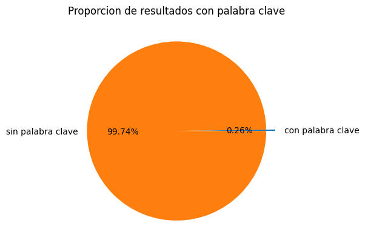

```r
py_run_string("
import matplotlib
matplotlib.use('Agg') #configura matplotlib para que no intente abrir ventanas flotantes
import matplotlib.pyplot as plt

plt.close('all')
total_palabra = len(tabla_resultados)
total = len(tabla)
sin_palabra = total - total_palabra

valores = [total_palabra, sin_palabra]
etiquetas = ['con palabra clave', 'sin palabra clave']

plt.pie(valores, labels=etiquetas, autopct='%1.2f%%', explode=(0.1, 0))

plt.title('Proporcion de resultados con palabra clave')

plt.savefig('grafico_pastel.png', bbox_inches='tight')
")

knitr::include_graphics("grafico_pastel.png")
```

- esto indica que dicho termino no es frecuente dentro del contenido de la API en el periodo seleccionado, con tan solo el 0.26% de los datos, lo que sugiere que este tipo de fenomeno no aparece de manera regular en las descripciones diarias

# 2. Para las búsquedas de tu palabra, ¿en qué rangos de fechas se introdujo el recurso?

```r
py_run_string('
print(tabla_resultados["date"].min(), tabla_resultados["date"].max())
')
```

```
2001-12-20 00:00:00 2026-01-31 00:00:00
```

# 3. Para las búsquedas de tu palabra, ¿cuáles son los “media_type” más comunes?

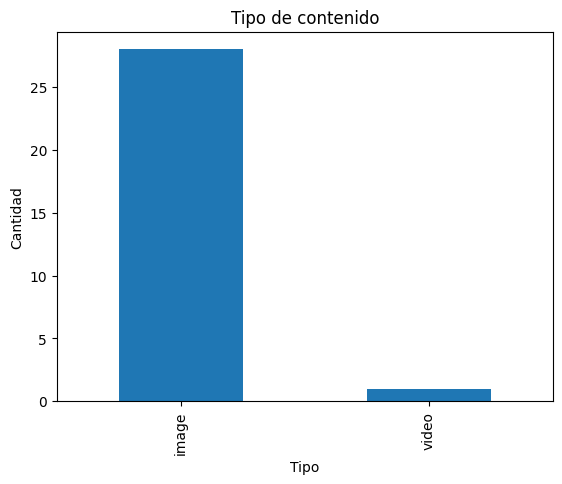

```r
py_run_string("
plt.figure()  # crea una figura nueva
tabla_resultados['media_type'].value_counts().plot(kind='bar')

plt.title('Tipo de contenido')
plt.xlabel('Tipo')
plt.ylabel('Cantidad')
plt.savefig('grafico_barras.png', bbox_inches='tight')
")

knitr::include_graphics("grafico_barras.png")
```

- existe una clara predominancia de imagenes frente a los videos, con un total de 28 fotografias y un solo video
- investigando un poco, esta diferencia se debe a que el movimiento `retroograde` es un fenomeno de larga duracion, cuya representacion visual mas efectiva es la composicion fotografica de múltiples exposiciones tomada a lo largo de varios meses

# 4. Para las búsquedas de tu palabra, ¿quiénes son los autores o instituciones propietaria de los derechos (i.e. el copyright)?

```r
py_run_string('
print(tabla_resultados["copyright"].value_counts())
')
```

```
copyright
Tunc Tezel                                                  14
Sin Autor                                                   11
Peter Wienerroither                                          1
John Pane                                                    1
Western U., Athabasca U., Large Binocular Telescope Obs.     1
John Kraus                                                   1
Name: count, dtype: int64
```

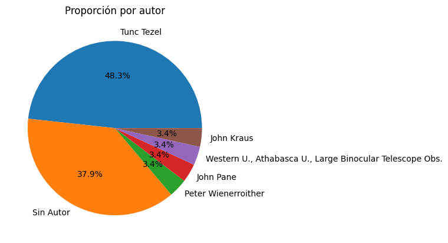

```r
py_run_string("
plt.figure()
tabla_resultados['copyright'].value_counts().plot(kind='pie', autopct='%1.1f%%')

plt.title('Proporción por autor')
plt.ylabel('')
plt.savefig('grafico_autores.png', bbox_inches='tight')
")

knitr::include_graphics("grafico_autores.png")
```

- Tunc Tezel destaca como el principal contribuyente con 14 menciones, representando el 48.3%, casi la mitad, seguido por un volumen significativo de obras de propiedad de la NASA, sin autor especificado con 11 registros (37.9%), el porcentaje restante se distribuye equitativamente entre otros autores e instituciones
- investigando un poco, Tezel es un astronomo aficionado , fotografo e ingeniero civil turco, miembro de The World at Night (TWAN), un programa internacional en el que fotografos de todo el mundo capturan imagenes de cielos nocturnos vistos desde puntos de referencia notables del planeta
- esto sugiere que el contenido sobre `retrogade` en APOD depende de colaboraciones con especialistas como Tezel mas que de capturas automaticas de satelites